# Addressing Reviewer Comments

```r
library(dplyr)
```

```r
library(ggplot2)
library(cowplot)
options(stringsAsFactors = F)
options(scipen = 10000)

snv_data <- read.table('../processed_data/exac/exac_func_annot.txt',
                       sep = '\t', header = T)
sre_data <- read.table('../processed_data/splicemod/splicemod_data_clean.txt',
                       sep = '\t', header = T)
```

## Reviewer 1

### 1b.

“62.2% of 2902 WT exons in SNV library have index > 0.80. This seems low given these exons are represented in the exome-sequencing data (ExAC).”

```r
num_natural <- snv_data %>% filter(category == 'natural') %>% nrow()
snv_data %>%
    filter(category == 'natural', v2_index >= 0.80) %>%
    summarise(n() / num_natural)
```

| n()/num_natural |
| --- |
| 0.9147514 |

```r
num_natural <- sre_data %>% filter(seq_type == 'nat') %>% nrow()
num_nat_dhfr <- sre_data %>% filter(seq_type == 'nat', !is.na(index_dhfr)) %>% nrow()
num_nat_smn1 <- sre_data %>% filter(seq_type == 'nat', !is.na(index_smn1)) %>% nrow()

sre_data %>%
    filter(seq_type == 'nat', index_dhfr >= 0.80) %>%
    summarise(n() / num_nat_dhfr)
```

| n()/num_nat_dhfr |
| --- |
| 0.5857724 |

```r
sre_data %>%
    filter(seq_type == 'nat', index_dhfr >= 0.50) %>%
    summarise(n() / num_nat_dhfr)
```

| n()/num_nat_dhfr |
| --- |
| 0.670122 |

The percentage of included WT exons > 0.80 at 91% in the SNV library. The 62.% we state is from the SRE library. My numbers show that 58% (2882/4920) of WT exons have index > 0.80 and and 67% (3297/4920) > 0.50 in the DHFR backbone. The reviewer misunderstood the number, which we can make more clear.

### 1c

How comparable are the DHFR and SMN1 backbone, we mention that DHFR is more reproducible.

```r
sre_data %>%
    filter(!is.na(index_dhfr)) %>% nrow() %>% print()
```

```
## [1] 13922
```

```r
sre_data %>%
    filter(!is.na(index_smn1)) %>% nrow() %>% print()
```

```
## [1] 18602
```

```r
sre_data %>%
    filter(!is.na(index_smn1), !is.na(index_dhfr)) %>% nrow() %>% print()
```

```
## [1] 11960
```

```r
cor.test(sre_data$index_smn1, sre_data$index_dhfr, use = 'p')
```

```
##
##  Pearson's product-moment correlation
##
## data:  sre_data$index_smn1 and sre_data$index_dhfr
## t = 173.28, df = 11958, p-value < 0.00000000000000022
## alternative hypothesis: true correlation is not equal to 0
## 95 percent confidence interval:
##  0.8405001 0.8507116
## sample estimates:
##       cor
## 0.8456832
```

Fig 1E. shows correlatin of 0.94 for DHFR biological replicates, 0.89 for SMN1, and shows correlation between the two is 0.85. We actually recover more sequences with SMN1 than DHFR, but choose DHFR for it’s replicability. I’m not sure what further evidence could show that the results are generalizable across backbones.

### 5. Why are some exons highly expressed in SMN1 but not DHFR?

```r
high_smn1_low_dhfr <- sre_data %>%
    mutate(discordance = index_smn1 - index_dhfr) %>%
    filter(discordance >= 0.50)

table(high_smn1_low_dhfr$seq_type)
```

```
##
## control     mut     nat
##       1     528     252
```

```r
high_smn1_low_dhfr %>%
    group_by(category) %>%
    summarise(count = n()) %>%
    arrange(desc(count))
```

| category | count |
| --- | --- |
| NA | 253 |
| rnd_intron_2nt | 41 |
| RBPmats | 40 |
| aggr_intron | 35 |
| rnd_intron_1nt | 35 |
| clst_Ke2011_ESE | 29 |
| p_aggr_intr | 24 |
| clst_Vlkr07_AICS | 22 |
| rmv_Vlkr07_DICS | 20 |
| weak_spl_a | 20 |

[output cut: 26 more lines]

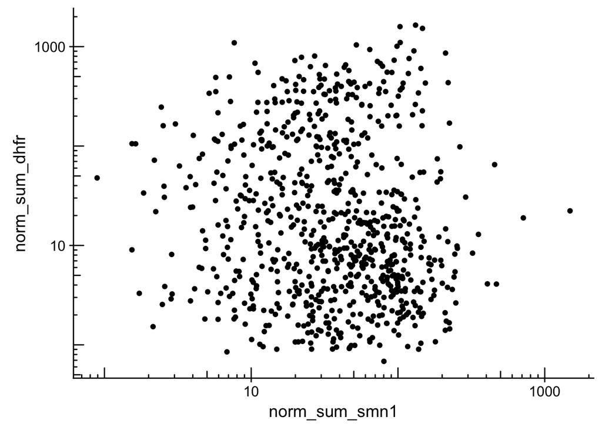

```r
ggplot(high_smn1_low_dhfr, aes(norm_sum_smn1, norm_sum_dhfr)) + geom_point() +
    scale_x_log10() + scale_y_log10() + annotation_logticks(sides = 'bl')
```

## Reviewer 2

### 1. Scatter plots Fig 1E

Blue/black/grey colors are difficult to see. Bump up alpha to make it less transparent can improve clarity without changing colors. Example plot:

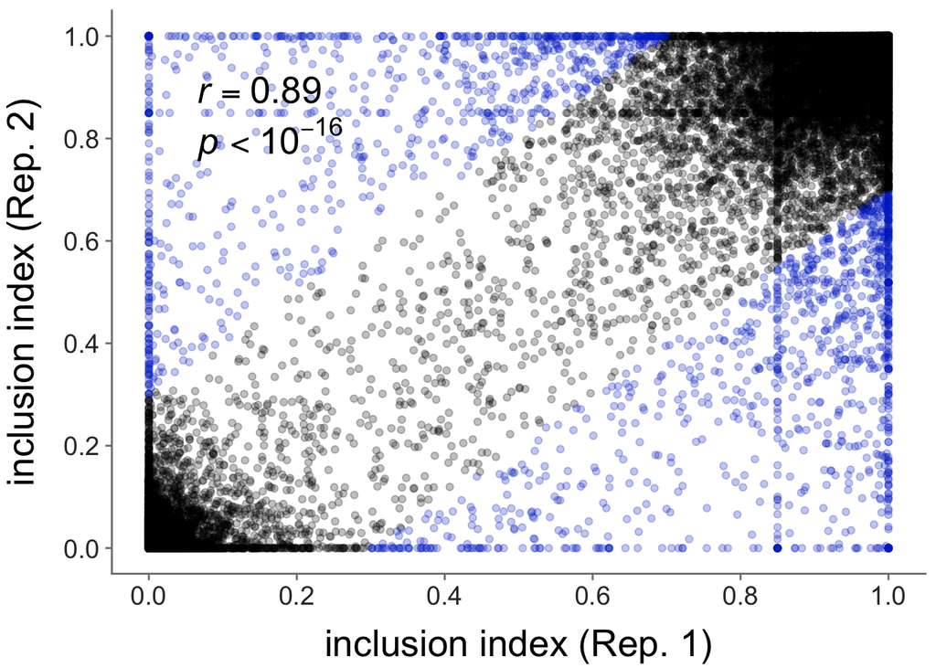

```r
# Index across SMN1 biological replicates
corr <- signif(cor(sre_data$index_R1_smn1, sre_data$index_R2_smn1, use = 'p'), 2)
sre_data %>%
    ggplot(aes(index_R1_smn1, index_R2_smn1)) +
    geom_point(alpha = 0.25, aes(color = replicability_smn1)) +
    scale_x_continuous(breaks = c(0, 0.2, 0.4, 0.6, 0.8, 1)) +
    scale_y_continuous(breaks = c(0, 0.2, 0.4, 0.6, 0.8, 1)) +
    scale_color_manual(values = c('black', '#0033CC')) +
    labs(x = 'inclusion index (Rep. 1)', y = 'inclusion index (Rep. 2)') +
    theme(legend.position = 'none',
          axis.title.x = element_text(size = 20, vjust = -2),
          axis.title.y = element_text(size = 20, vjust = +4),
          axis.text.x = element_text(size = 14, color = 'grey20'),
          axis.text.y = element_text(size = 14, color = 'grey20'),
          axis.ticks.x = element_line(color = 'grey50'),
          axis.ticks.y = element_line(color = 'grey50'),
          axis.line.x = element_line(color = 'grey50'),
          axis.line.y = element_line(color = 'grey50'),
          plot.margin = unit(c(2,2,3,3),"mm")) +
    annotate('text', x = 0.15, y = 0.895, size = 7, parse = T,
             label = paste("italic(r)==", signif(corr, 3))) +
    annotate('text', x = 0.165, y = 0.80, size = 7, parse = T,
             label = paste('italic(p) < 10^-16'))
```

## Motif Analysis

```r
# source("https://bioconductor.org/biocLite.R")
# biocLite("PWMEnrich")
# biocLite("PWMEnrich.Hsapiens.background")
# biocLite("MotifDb")
# biocLite('Biostrings')
library(PWMEnrich)
library(PWMEnrich.Hsapiens.background)
library(MotifDb)
library(Biostrings)
```

Making a custom background from the sequences in our SNV library takes too much memory, below is not evaluated.

```r
# grab all human motifs, position probability matrices
motifs <- query(MotifDb, 'hsapiens')
# convert to PWMs
pwm_motifs <- lapply(motifs, toPWM)
# create genomic background based on SNV library
bg_seqs <- DNAStringSet(filter(snv_data, category != 'control')$original_seq)
# background suitable for empirical p-value calculation. Background seqs are
# concatenated into one large seq, scanned for motifs, then save raw scores
makePWMEmpiricalBackground(bg_seqs, pwm_motifs)
```

Let’s use a pre-compiled background and only use the ~300 motifs from the CISBP-RNA database, a library of RNA binding proteins and their motifs.

The SDVs are probably breaking important motifs, so running enrichment directly on these will be challenging. Let’s instead grab the natural exons for the SDVs.

```r
registerCoresPWMEnrich(4)
# load pre-compiled background
data("PWMLogn.hg19.MotifDb.Hsap")
sdv_nat_seqs <- snv_data %>%
    filter(category != 'control', strong_lof == T) %>%
    select(ensembl_id) %>%
    distinct() %>%
    semi_join(snv_data, ., by = 'ensembl_id') %>%
    filter(category == 'natural') %>%
    select(original_seq, ensembl_id) %>%
    distinct()

sdv_nat_set <- DNAStringSet(sdv_nat_seqs$original_seq)
```

```r
 # grab all CISBP-RNA binding motifs, position probability matrices
cisbp_motifs <- query(query(MotifDb, 'Hsapiens'), 'cispb')
# convert to PWMs, for some reason IDs do not propagate through
pwm_motifs <- lapply(cisbp_motifs, toPWM)
bg_cisbp <- makeBackground(pwm_motifs, organism = 'hg19', quick = T)
```

[output not shown]

[output cut: 1519 more lines]

[output not shown]

```r
# PWMEnrich motif set only contains CIS-BP TF PWMs
#  this is slow
motif_enrichment <- motifEnrichment(sdv_nat_set, bg_cisbp)
```

```
## Parallel scanning with 4 cores
## Calculating motif enrichment scores ...
```

```r
report = sequenceReport(motif_enrichment, 1)
report
```

```
## An object of class 'MotifEnrichmentReport':
##     rank target  id          raw.score             p.value
## 1      1              10.0109904596857 0.00872111640308638
## 2      2              1.75879866588468  0.0161415053140738
## 3      3              5.61215978685368  0.0214100388345487
## 4      4              43.8245052358335  0.0534898955833912
## 5      5              5.86964032733345  0.0559860324139247
## 6      6              28.1259773711082  0.0580896970640445
## 7      7              40.4342788860559  0.0646318849283192
## 8      8              5.89244617318437  0.0723163677963894
## 9      9              2.42258404538054  0.0808900624880971
## 10    10              2.58765846016769  0.0936165160811414
## ...  ...    ... ...                ...                 ...
## 313  313            0.0215996974257514   0.976263965190502
```

```r
signif_report = report[report$p.value < 0.05]
signif_report
```

```
## An object of class 'MotifEnrichmentReport':
##   rank target id raw.score     p.value
## 1    1           10.010990 0.008721116
## 2    2            1.758799 0.016141505
## 3    3            5.612160 0.021410039
```

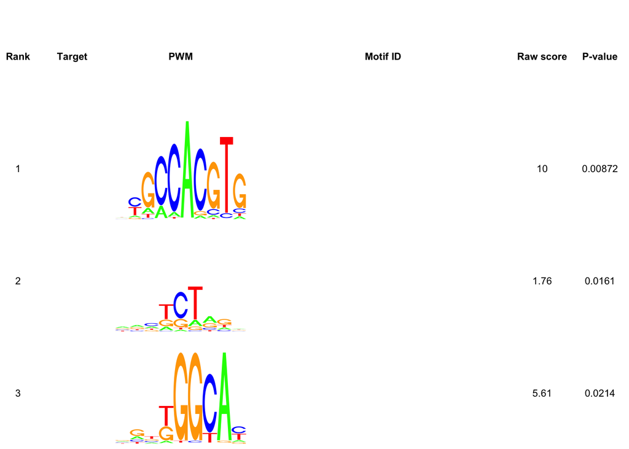

```r
plot(signif_report, fontsize = 8, id.fontsize = 7)
```

For some reason the target and motif IDs don’t propagate when converting from PFM to PWM, can get the names below.

```r
motif_info <- data.frame(id = sapply(strsplit(names(report$pwms), '-'), `[[`, 3),
                         p.value = report$p.value)
```

You can download more information from the CIS-BP website (http://cisbp.ccbr.utoronto.ca/bulk.php) which includes a TF information file.

Pulling information from the `TF_Information_all_motifs_plus.txt` file:

```r
tf_info <- read.table('../ref/cisbp_hsapiens/TF/TF_Information_all_motifs_plus.txt',
                      header = T, sep = '\t', fill = T)

motif_info <- motif_info %>%
    left_join(tf_info, by = c('id' = 'Motif_ID'))
```

PWMEnrich only contains TF binding sites, let’s look at the RNA binding protein sites also availble from CISBP. To get at positional information, let’s use matchPWM. Also, it’s a pain to create PWMs for PWMEnrich from text files.

```r
# load in motifs
read_pwm_from_file <- function(filename) {
    if(file.size(filename) == 0) { return(NULL) }
    df <- read.table(filename, sep = '\t', header = T)
    # convert to matrix, transpose so rows are nucleotides. Get rid of the
    # position columns in first row
    pwm <- t(data.matrix(df))[-1,]
    dimnames(pwm)[[1]] <- c('A', 'C', 'G', 'T')
    return(pwm)
}

files <- list.files('../ref/cisbp_hsapiens/RBP/pwms_all_motifs', full.names = T)
# get motif names
motif_names <- gsub('.txt', '', list.files('../ref/cisbp_hsapiens/RBP/pwms_all_motifs'))
cisbp_rna_pwms <- lapply(as.list(files), function(x) read_pwm_from_file(x))
names(cisbp_rna_pwms) <- motif_names
# some motifs were empty, remove these from list
cisbp_rna_pwms <- cisbp_rna_pwms[!sapply(cisbp_rna_pwms, is.null)]
print(length(cisbp_rna_pwms))
```

```
## [1] 193
```

Let’s scan each PWM over each sequence.

```r
sdv_nat_strings <- lapply(as.list(sdv_nat_seqs$original_seq), DNAString)
scan_all_pwms <- function(pwms, sequence) {
    all_pwms_result <- lapply(pwms, function(x) matchPWM(x, sequence, with.score = T))
    return(all_pwms_result)
}

pwm_hits_all <- lapply(sdv_nat_strings, function(x) scan_all_pwms(cisbp_rna_pwms, x))
# get rid of motifs with no hit
filter_hits <- function(hit_list) {
    filtered <- hit_list[which(unlist(lapply(hit_list, function(x) length(mcols(x)$score) != 0)))]
    return(filtered)
}
pwm_hits <- lapply(pwm_hits_all, function(x) filter_hits(x))
```

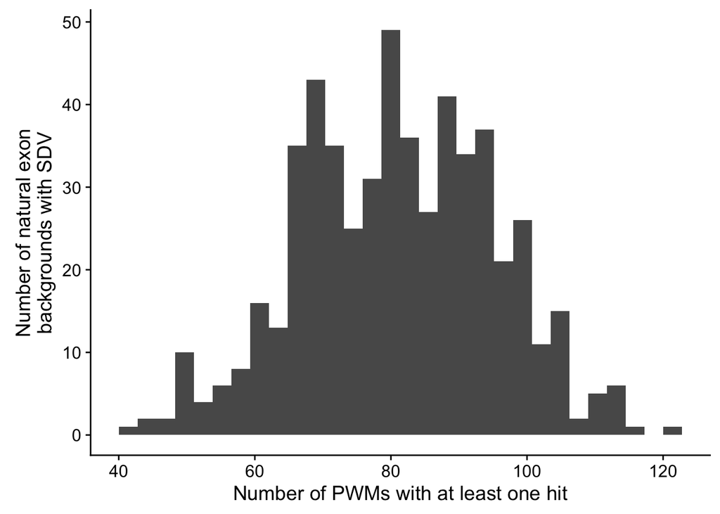

```r
sdv_nat_seqs$num_pwm_hits <- sapply(pwm_hits, length)
ggplot(sdv_nat_seqs, aes(num_pwm_hits)) + geom_histogram() +
    labs(x = 'Number of PWMs with at least one hit',
         y = 'Number of natural exon\nbackgrounds with SDV')
```

```r
summary(sdv_nat_seqs$num_pwm_hits)
```

```
##    Min. 1st Qu.  Median    Mean 3rd Qu.    Max.
##   41.00   70.00   81.00   80.94   91.00  121.00
```

Create data frame for all of this data. For each hit, list the RBP motif name, start, end, width, score, and sequence hit.

```r
create_pwm_df <- function(pwm_list, rev = F) {
    scores <- sapply(pwm_list, function(x) mcols(x)$score)
    df <- data.frame(score = unlist(scores),
                     motif_id = names(unlist(scores)))
    # all PWMs for same sequence, grab it
    seq <- as.character(subject(pwm_list[[1]]))
    if(rev) {
        seq = as.character(reverseComplement(DNAString(seq)))
    }
    df$subject_seq <- rep(seq, nrow(df))
    df$start <- unlist(sapply(pwm_list, function(x) start(as(x, 'IRanges'))))
    df$end <- unlist(sapply(pwm_list, function(x) end(as(x, 'IRanges'))))
    return(df)
}

pwm_dfs <- lapply(pwm_hits, create_pwm_df)
pwm_df_master <- do.call('rbind', pwm_dfs)
pwm_df_master <- pwm_df_master %>%
    left_join(sdv_nat_seqs, by = c('subject_seq' = 'original_seq')) %>%
    mutate(match_strand = 1)
```

Now let’s do this all again but searching on the reverse strand.

```r
pwm_hits_all_rc <- lapply(lapply(sdv_nat_strings, reverseComplement),
                          function(x) scan_all_pwms(cisbp_rna_pwms, x))

pwm_hits_rc <- lapply(pwm_hits_all_rc, function(x) filter_hits(x))

pwm_dfs_rc <- lapply(pwm_hits_rc, function(x) create_pwm_df(x, rev = T))
pwm_df_rc <- do.call('rbind', pwm_dfs_rc)
pwm_df_rc <- pwm_df_rc %>%
    left_join(sdv_nat_seqs, by = c('subject_seq' = 'original_seq')) %>%
    mutate(match_strand = -1)

pwm_df_master <- bind_rows(pwm_df_master, pwm_df_rc)

# ending of motif ID (the version number) altered when unlisting, just remove it
# from the end
pwm_df_master$motif_id <- sapply(strsplit(pwm_df_master$motif_id, "_"), `[`, 1)

rm(pwm_df_rc, pwm_dfs, pwm_dfs_rc)
```

Let’s pull SDVs from the SNV dataset and calculate relative position to the start of the sequence (for matches on positive strand) and from the end (matches on reverse strand)

```r
sdv_subset <- snv_data %>%
    filter(strong_lof == T, category != 'control') %>%
    mutate(rel_position_start = snp_position - start + 1,
           rel_position_end = end - snp_position + 1) %>%
    select(id, ensembl_id, v2_dpsi, mean_cons_score,
           rel_position_scaled, rel_position_start, rel_position_end)

sdv_nat_exon_hits <- sdv_subset %>%
    left_join(pwm_df_master, by = 'ensembl_id') %>%
    data.frame()

overlap <- function(position, start, end) {
    overlap <- findInterval(position, c(start, end))
    if(overlap == 1) {
        return(TRUE)
    }
    else{ return(FALSE)}
}

# annotate if SDV overlaps motif
sdv_nat_exon_hits <- sdv_nat_exon_hits %>%
    # sample_n(10) %>%
    rowwise() %>%
    mutate(sdv_pwm_overlap = ifelse(match_strand == 1,
                                    overlap(rel_position_start, start, end),
                                    overlap(rel_position_end, start, end))) %>%
    ungroup()
```

```r
sdv_nat_exon_hits %>%
    group_by(ensembl_id) %>%
    mutate(sdv_pwm_overlap_any = any(sdv_pwm_overlap)) %>%
    ungroup() %>%
    select(id, -ensembl_id, v2_dpsi, rel_position_scaled, sdv_pwm_overlap_any) %>%
    distinct(.keep_all = T) %>%
    count(sdv_pwm_overlap_any)
```

| sdv_pwm_overlap_any | n |
| --- | --- |
| FALSE | 5 |
| TRUE | 1045 |

Most SDVs overlap with at least 1 PWM hit (out of 193 potential motifs). Let’s count the number of PWM overlaps for each SDV. There may be multiple hits for the same PWM.

```r
sdv_subset <- sdv_nat_exon_hits %>%
    group_by(ensembl_id) %>%
    mutate(num_sdv_pwm_overlap = length(which(sdv_pwm_overlap))) %>%
    ungroup() %>%
    select(id, num_sdv_pwm_overlap) %>%
    distinct(.keep_all = T) %>%
    right_join(sdv_subset, by = 'id')
```

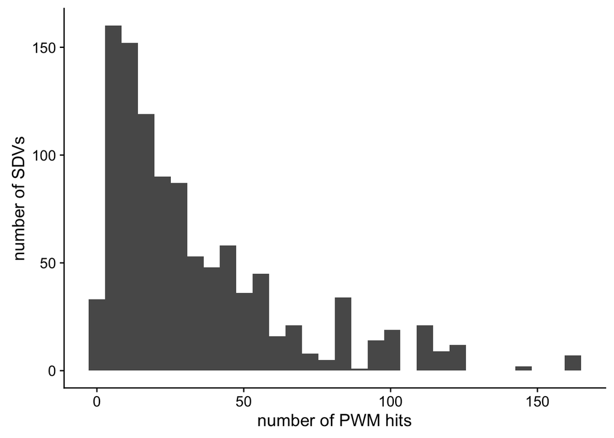

```r
ggplot(sdv_subset, aes(num_sdv_pwm_overlap)) + geom_histogram() +
    labs(x = 'number of PWM hits', y = 'number of SDVs')
```

Let’s try to filter this down so we get number of distinct PWM hits, so only one hit per motif.

```r
sdv_subset <- sdv_nat_exon_hits %>%
    group_by(ensembl_id, motif_id) %>%
    mutate(sdv_pwm_overlap_motif = any(sdv_pwm_overlap)) %>%
    ungroup() %>%
    select(id, ensembl_id, motif_id, sdv_pwm_overlap_motif) %>%
    distinct() %>%
    group_by(id) %>%
    mutate(num_sdv_pwm_overlap_unique = length(which(sdv_pwm_overlap_motif))) %>%
    ungroup() %>%
    select(id, num_sdv_pwm_overlap_unique) %>%
    distinct(.keep_all = T) %>%
    right_join(sdv_subset, by = 'id')
```

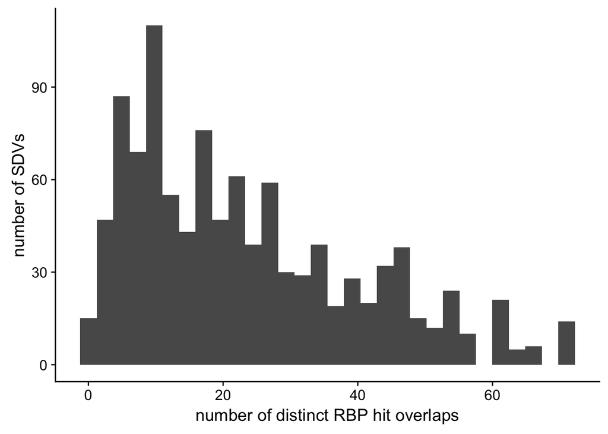

```r
ggplot(sdv_subset, aes(num_sdv_pwm_overlap_unique)) + geom_histogram() +
    labs(x = 'number of distinct RBP hit overlaps',
         y = 'number of SDVs')
```

```r
rbp_info <- read.table('../ref/cisbp_hsapiens/RBP/RBP_Information_all_motifs.txt',
                       sep = '\t', header = T)

sdv_nat_exon_hits <- sdv_nat_exon_hits %>%
    mutate(motif_id = paste0(motif_id, '_0.6')) %>%
    left_join(select(rbp_info, motif_id = Motif_ID, DBID, RBP_Name), by = 'motif_id')
```